# Lista 2 Bayesiana

Davi Wentrick Feijó - 200016806

2024-12-02

### **Questao 1**

O seu professor chega na sala de aula e mostra uma moeda. Você suspeita que a moeda possa ser falsa e ter duas caras. Considere a priori probabilidades iguais para os eventos da moeda ser falsa ou ser honesta (i.e. uma moeda bem equilibrada).

##### **(i)** Calcule a sua probabilidade de obter cara num lançamento dessa moeda.

**Dados:**

- Probabilidade de a moeda ser honesta: $P(H) = 0.5$
- Probabilidade de a moeda ser falsa: $P(F) = 0.5$
- Probabilidade de obter “cara” com moeda honesta: $P(C_1 \mid H) = 0.5$
- Probabilidade de obter “cara” com moeda falsa: $P(C_1 \mid F) = 1$

**Fórmula da probabilidade total:**
$$P(C_1) = P(C_1 \mid H)P(H) + P(C_1 \mid F)P(F)$$

**Cálculo:**
$$P(C_1) = (0.5 \times 0.5) + (1 \times 0.5) \\
P(C_1) = 0.25 + 0.5 = 0.75$$

**Resultado:** A probabilidade de obter “cara” no primeiro lançamento é **0.75**.

##### **(ii)** Se o professor lançar a moeda e o resultado for cara, qual é agora a probabilidade dela ser falsa?

Queremos calcular: $P(F \mid C_1)$, a probabilidade de a moeda ser falsa dado que o resultado foi “cara”.

**Usando o Teorema de Bayes:**

$$P(F \mid C_1) = \frac{P(C_1 \mid F) P(F)}{P(C_1)}$$

**Dados:**

- $P(C_1 \mid F) = 1$ (se a moeda é falsa, sempre dá “cara”).
- $P(F) = 0.5$ (a priori, a moeda tem 50% de chance de ser falsa).
- $P(C_1) = 0.75$ (calculado anteriormente).

**Cálculo:**

$$P(F \mid C_1) = \frac{P(C_1 \mid F) P(F)}{P(C_1)} = \frac{1 \times
0.5}{0.75} = \frac{0.5}{0.75} = \frac{2}{3}$$

**Resultado:** A probabilidade de a moeda ser falsa, dado que o resultado do lançamento foi “cara”, é $\frac{2}{3}$ ou aproximadamente **66.67%**.

##### **(iii)** Se o professor lançar a moeda $n$ vezes e obter $n$ caras, qual é a probabilidade dela ser falsa? Estude o comportamento desta probabilidade para $n$ grande.

**Queremos calcular:** $P(F \mid C^n)$, a probabilidade de a moeda ser falsa dado que todos os $n$ lançamentos resultaram em “cara”.

**Usando o Teorema de Bayes:**

$$P(F \mid C^n) = \frac{P(C^n \mid F) P(F)}{P(C^n)}$$

**Dados:**

- $P(F) = 0.5$ (a priori, a moeda é falsa).
- $P(H) = 0.5$ (a priori, a moeda é honesta).
- $P(C^n \mid F) = 1$ (se a moeda é falsa, todos os $n$ lançamentos resultam em “cara”).
- $P(C^n \mid H) = 0.5^n$ (se a moeda é honesta, a probabilidade de obter $n$ caras é $0.5^n$).

**Probabilidade total $P(C^n)$:**

$$P(C^n) = P(C^n \mid H)P(H) + P(C^n \mid F)P(F) \\
P(C^n) = (0.5^n \times 0.5) + (1 \times 0.5) = 0.5^{n+1} + 0.5$$

**Substituímos na fórmula de Bayes:**

$$P(F \mid C^n) = \frac{P(C^n \mid F) P(F)}{P(C^n)} = \frac{1 \times
0.5}{0.5^{n+1} + 0.5}$$

**Comportamento para $n$ grande:**

- O termo $0.5^n$ decresce exponencialmente para $n$ grande.
- Assim, $0.5^{n+1} \to 0$, e a expressão se simplifica:

$$P(F \mid C^n) \approx \frac{0.5}{0.5} = 1$$

**Resultado:**

Conforme $n \to \infty$, a probabilidade de a moeda ser falsa tende a **1** (ou 100%).

**Conclusão:** Se o professor lançar a moeda $n$ vezes e obter $n$ caras, a probabilidade de a moeda ser falsa se aproxima de 1 conforme $n$ aumenta.

##### **(iv)** Se o professor lançar a moeda uma vez e obter cara, qual é a probabilidade do próximo lançamento ser cara?

**Queremos calcular:** $P(C_2 \mid C_1)$, a probabilidade de obter “cara” no próximo lançamento dado que o primeiro lançamento resultou em “cara”.

**Passos:**

1. Após o primeiro lançamento resultar em “cara”, a probabilidade de a moeda ser falsa ($P(F \mid C_1)$) foi calculada como:

$$P(F \mid C_1) = \frac{2}{3}$$
A probabilidade de a moeda ser honesta ($P(H \mid C_1)$) é:

$$P(H \mid C_1) = 1 - P(F \mid C_1) = 1 - \frac{2}{3} = \frac{1}{3}$$

2. Usamos a fórmula:

$$P(C_2 \mid C_1) = P(C_2 \mid F)P(F \mid C_1) + P(C_2 \mid H)P(H \mid
C_1)$$

**Dados:**

- $P(C_2 \mid F) = 1$ (se a moeda é falsa, sempre dá “cara”).
- $P(C_2 \mid H) = 0.5$ (se a moeda é honesta, a probabilidade de “cara” é 0.5).
- $P(F \mid C_1) = \frac{2}{3}$, $P(H \mid C_1) = \frac{1}{3}$.
3. Substituímos os valores:

$$P(C_2 \mid C_1) = \left(1 \times \frac{2}{3}\right) + \left(0.5
\times \frac{1}{3}\right) \\
P(C_2 \mid C_1) = \frac{2}{3} + \frac{1}{6} \\
P(C_2 \mid C_1) = \frac{4}{6} + \frac{1}{6} = \frac{5}{6} \\$$

**Resultado:**

A probabilidade de obter “cara” no próximo lançamento, dado que o primeiro lançamento resultou em “cara”, é:

$$P(C_2 \mid C_1) = \frac{5}{6} \approx 83.33\%$$

##### **(v)** Explique porque é falso neste contexto a afirmação “os dois lançamentos da moeda são independentes”, e explique qual seria a afirmação correta.

**Contexto:** A afirmação “os dois lançamentos da moeda são independentes” é **falsa** porque o resultado de cada lançamento influencia nossa crença sobre a natureza da moeda (se ela é honesta ou falsa). Essa mudança na crença altera as probabilidades dos resultados subsequentes.

Dois eventos $A$ e $B$ são independentes se, e somente se:

$$P(A \cap B) = P(A) \cdot P(B)$$

Ou, de forma equivalente:

$$P(B \mid A) = P(B)$$
Se os lançamentos fossem independentes, o resultado de um lançamento não alteraria a probabilidade do próximo. Porém, neste contexto:

1. O resultado do primeiro lançamento ($C_1$) altera nossa crença sobre a natureza da moeda.
2. Essa mudança de crença afeta a probabilidade do segundo lançamento ($C_2$).

Por exemplo:

- A probabilidade do segundo lançamento resultar em “cara”, $P(C_2 \mid C_1)$, é calculada considerando a probabilidade de a moeda ser honesta ou falsa, que depende do resultado do primeiro lançamento.
- Assim, $P(C_2 \mid C_1) \neq P(C_2)$, evidenciando que os lançamentos não são independentes.

A afirmação correta seria: **“Os dois lançamentos da moeda são condicionalmente independentes.”**

Isso significa que:

- Quando fixamos um (moeda verdadeira ou moeda falsa) estamos removendo a incerteza do problema o que causaria que os lancamentos voltariam a ser independentes ja que saberiamos que estamos trabalhando com uma moeda especifica e nao teriamos que modelar a incerteza de poder estar trabalhando com a outra.

### **Questao 2**

Seja $y_1, y_2, \ldots, y_n$ uma amostra da distribuição de Bernoulli com probabilidade de sucesso $\theta$ e considere uma distribuição a priori uniforme para $\theta$.

##### **(i)** Ache a distribuição a posteriori de $\theta$ e a sua média e variância.

**Dado:**

- A função de probabilidade de uma variável Bernoulli é:

$$P(X=x \mid p)=p^x(1-p)^{1-x}, \quad x \in\{0,1\}$$

- A verossimilhança para uma amostra de Bernoulli é:

$$\begin{align*}
P\left(y_1, y_2, \ldots, y_n \mid \theta\right) &= \prod_{i=1}^n
\theta^{y_i}(1-\theta)^{1-y_i} \\
&= \theta^{\sum_{i=1}^n y_i}(1-\theta)^{n-\sum_{i=1}^n y_i} \\
&= \theta^k(1-\theta)^{n-k}, \quad \text{onde } k = \sum_{i=1}^n y_i
\end{align*}$$

- A priori de $\theta$ é uniforme no intervalo $[0,1]$:

$$P(\theta) = 1, \quad \text{para } \theta \in [0,1]$$

**Distribuição a Posteriori:**

$$P(\theta \mid y_1, y_2, \ldots, y_n) \propto P(y_1, y_2, \ldots, y_n
\mid \theta) \cdot P(\theta)$$

Substituindo:

$$\begin{align*}
P\left(\theta \mid y_1, y_2, \ldots, y_n\right) &\propto
\theta^k(1-\theta)^{n-k} \cdot 1 \\
P(\theta \mid y_1, y_2, \ldots, y_n) &\propto
\theta^k(1-\theta)^{n-k}
\end{align*}$$

Essa é a forma de uma distribuição **Beta** com parâmetros:

$$\theta \mid y_1, y_2, \ldots, y_n \sim \text{Beta}(k+1, n-k+1)$$

Para uma distribuição $\text{Beta}(\alpha, \beta)$:

- Média:

$$\mathbb{E}[\theta] = \frac{\alpha}{\alpha + \beta}$$

- Variância:

$$\text{Var}(\theta) = \frac{\alpha \beta}{(\alpha + \beta)^2 (\alpha +
\beta + 1)}$$

**Substituindo os Parâmetros:**

- $\alpha = k+1$, $\beta = n-k+1$

**Média:**

$$\mathbb{E}[\theta \mid y_1, y_2, \ldots, y_n] = \frac{k+1}{(k+1) +
(n-k+1)} = \frac{k+1}{n+2}$$

**Variância:**

$$\begin{align*}
\text{Var}[\theta \mid y_1, y_2, \ldots, y_n] &=
\frac{(k+1)(n-k+1)}{((k+1)+(n-k+1))^2((k+1)+(n-k+1)+1)} \\ \\
&= \frac{(k+1)(n-k+1)}{(n+2)^2(n+3)}
\end{align*}$$

1. A distribuição a posteriori de $\theta$ é:

$$\theta \mid y_1, y_2, \ldots, y_n \sim \text{Beta}(k+1, n-k+1)$$

2. A média da posteriori é:

$$\mathbb{E}[\theta \mid y_1, y_2, \ldots, y_n] = \frac{k+1}{n+2}$$

3. A variância da posteriori é:

$$\text{Var}[\theta \mid y_1, y_2, \ldots, y_n] =
\frac{(k+1)(n-k+1)}{(n+2)^2(n+3)}$$

##### **(ii)** Mostre que é possível expressar a esperança a posteriori de $\theta$ da forma $(1-w) E(\theta)+w \hat{\theta}$, onde $E(\theta)$ e $\hat{\theta}$ são respectivamente a esperança a priori e a estimativa máximo verossímil de $\theta$, e interprete este resultado.

Dado:

- A distribuição a posteriori de $\theta$ é:

$$\theta \mid y_1, y_2, \ldots, y_n \sim \text{Beta}(k+1, n-k+1)$$

- A esperança a posteriori é:

$$\mathbb{E}[\theta \mid y_1, y_2, \ldots, y_n] = \frac{k+1}{n+2}$$

- A priori, $\theta \sim \text{Uniforme}(0,1)$, cuja esperança é:

$$\mathbb{E}[\theta] = \frac{1}{2}$$

- A estimativa de máxima verossimilhança (MLE) para $\theta$ em uma amostra Bernoulli é:

$$\hat{\theta} = \frac{k}{n}$$

Queremos mostrar que:

$$\mathbb{E}[\theta \mid y_1, y_2, \ldots, y_n] = \frac{k+1}{n+2}$$

pode ser escrita como uma média ponderada entre $\mathbb{E}[\theta] = \frac{1}{2}$ (a priori) e $\hat{\theta} = \frac{k}{n}$ (MLE).

$$\mathbb{E}[\theta \mid y_1, y_2, \ldots, y_n] = (1-w) \cdot E(\theta)+w
\cdot \hat{\theta}$$

Vamos calcular o $w$, para isso vamos substituir os dados que conhecemos na formula e isolar o $w$. Substituindo os resultados na equacao dada pela questao:

$$\begin{align*}
\frac{k+1}{n+2} &= (1-w) \cdot \frac{1}{2}+w \cdot \frac{k}{n} \\
\frac{k+1}{n+2} &= \frac{1}{2}-\frac{w}{2} +w \cdot \frac{k}{n} \\
\frac{k+1}{n+2} - \frac{1}{2} &= -\frac{w}{2} +w \cdot \frac{k}{n}
\\
\frac{k+1}{n+2} - \frac{1}{2} &= w(\frac{k}{n}-\frac{1}{2}) \\
\end{align*}$$

Vamos resolver o lado esquerdo da igualdade e depois substituir o valor obtido para dar continuidade as contas:

$$\begin{align*}
\frac{k+1}{n+2} - \frac{1}{2} &= \frac{2(k+1)-(n+2)}{(n+2)\cdot 2}
\\
&= \frac{k+1}{n+2}-\frac{n+2}{2(n+2)} \\
&= \frac{k+1-\frac{n+2}{2}}{n+2} \\
&= \frac{k-\frac{n}{2}}{n+2} \\
\end{align*}$$

Voltando a conta e substituindo o valor encontrado temos:

$$\begin{align*}
\frac{k+1}{n+2} - \frac{1}{2} &= w(\frac{k}{n}-\frac{1}{2}) \\
\frac{k-\frac{n}{2}}{n+2} &= w(\frac{k}{n}-\frac{1}{2}) \\
\end{align*}$$
Isolando o $W$:

$$\begin{align*}
w &= \frac{\frac{k-\frac{n}{2}}{n+2}}{\frac{k}{n}-\frac{1}{2}} \\\\
&= \frac{\frac{k-\frac{n}{2}}{n+2}}{\frac{2k-n}{2n}} \\\\
&= \frac{k-\frac{n}{2}}{n+2}\frac{2n}{2k-n} \\\\
&= \frac{\frac{2k-n}{2}}{n+2}\frac{2n}{2k-n} \\\\
&= \frac{2k-n}{2(n+2)}\frac{2n}{2k-n} \\\\
&= \frac{1}{2(n+2)}\frac{2n}{1} \\\\
&= \frac{2n}{2(n+2)} \\\\
&= \frac{n}{n+2} \\\\
\end{align*}$$

Vamos verificar o resultado usando o valor encontrado para $w = \frac{n}{n+2}$:

$$\begin{align*}
\frac{k+1}{n+2} &= (1-w) \cdot \frac{1}{2}+w \cdot \frac{k}{n} \\
&= \left(1 - \frac{n}{n+2}\right) \cdot \frac{1}{2} + \frac{n}{n+2}
\cdot \frac{k}{n} \\
&= \frac{2}{n+2} \cdot \frac{1}{2} + \frac{n}{n+2} \cdot
\frac{k}{n} \\
&= \frac{1}{n+2} + \frac{k}{n+2} \\
&= \frac{k+1}{n+2}\\
\end{align*}$$

Definimos:

- $w = \frac{n}{n+2}$
- $1-w = \frac{2}{n+2}$

Assim mostramos que a esperança a posteriori segue a formula dada pela questao

##### **(iii)** Se $y_{n+1}$ é uma observação futura deste processo de Bernoulli, ache a distribuição preditiva $p\left(y_{n+1} \mid y_1, \ldots y_n\right)$.

A distribuição preditiva é dada por:

$$p(y_{n+1} \mid y_1, y_2, \ldots, y_n) = \int_0^1 p(y_{n+1} \mid \theta)
\cdot p(\theta \mid y_1, y_2, \ldots, y_n) \, d\theta$$

**Dados:**

1. $p(y_{n+1} \mid \theta)$ é Bernoulli com parâmetro $\theta$:

$$p(y_{n+1} \mid \theta) = \theta^{y_{n+1}} (1-\theta)^{1-y_{n+1}}$$

2. $p(\theta \mid y_1, y_2, \ldots, y_n)$ é a posteriori encontrada anteriormente:

$$p(\theta \mid y_1, y_2, \ldots, y_n) = \frac{\theta^k
(1-\theta)^{n-k}}{B(k+1, n-k+1)}$$

Para encontrar a distribuicao preditiva temos que encontrar os de $y_{n+1} = 0$ e $1$ (por seguir uma bernoulli), assim poderemos descrever o comportamento da distribuicao

- Para $y_{n+1} = 1$:

$$p(y_{n+1} = 1 \mid y_1, y_2, \ldots, y_n) = \int_0^1 \theta \cdot
\frac{\theta^k (1-\theta)^{n-k}}{B(k+1, n-k+1)} \, d\theta$$

Expandindo:

$$\begin{align*}
p(y_{n+1} = 1 \mid y_1, y_2, \ldots, y_n) &= \frac{1}{B(k+1, n-k+1)}
\int_0^1 \theta^{k+1-1} (1-\theta)^{n-k} \, d\theta \\ \\
& = \frac{B(k+2, n-k+1)}{B(k+1, n-k+1)}
\end{align*}$$
Utilizando a propriedade das funções Beta:

$$\begin{align*}
p(y_{n+1} = 1 \mid y_1, y_2, \ldots, y_n) &= \frac{B(k+2,
n-k+1)}{B(k+1, n-k+1)} \\ \\
& =\frac{\frac{\Gamma(k+2)
\Gamma(n-k+1)}{\Gamma\lceil(n+3)}}{\frac{T(k+1)
\Gamma(n-k+1)}{\Gamma(n+2)}} \\ \\
& =\frac{\Gamma(k+2) \Gamma(n-k+1)}{\Gamma(n+3)}
\frac{\Gamma(n+2)}{\Gamma(k+1) \Gamma(n-k+1)} \\ \\
& =\frac{\Gamma(k+2)}{\Gamma(n+3)} \frac{\Gamma(n+2)}{\Gamma(k+1)}
\\ \\
& =\frac{(k+1)\Gamma(k+1)}{(n+2)\Gamma(n+2)}
\frac{\Gamma(n+2)}{\Gamma(k+1)} \\ \\
&= \frac{k+1}{n+2}
\end{align*}$$

- Para $y_{n+1} = 0$:

$$p(y_{n+1} = 0 \mid y_1, y_2, \ldots, y_n) = \int_0^1 (1-\theta) \cdot
\frac{\theta^k (1-\theta)^{n-k}}{B(k+1, n-k+1)} \, d\theta$$

Expandindo:

$$\begin{align*}
p(y_{n+1} = 0 \mid y_1, y_2, \ldots, y_n) &= \frac{1}{B(k+1, n-k+1)}
\int_0^1 \theta^k (1-\theta)^{n-k+1-1} \, d\theta \\ \\
&= \frac{B(k+1, n-k+2)}{B(k+1, n-k+1)}
\end{align*}$$

Utilizando a propriedade das funções Beta:

$$\begin{align*}
p(y_{n+1} = 0 \mid y_1, y_2, \ldots, y_n) &= \frac{B(k+1,
n-k+2)}{B(k+1, n-k+1)} \\ \\
& =\frac{\frac{\Gamma(k+1)
\Gamma(n-k+2)}{\Gamma(n+3)}}{\frac{\Gamma(k+1)
\Gamma(n-k+1)}{\Gamma(n+2)}} \\ \\
& =\frac{\frac{\Gamma(n-k+2)}{\Gamma(n+3)}
}{\frac{\Gamma(n-k+1)}{\Gamma(n+2)}} \\ \\
& =\frac{\Gamma(n-k+2)}{\Gamma(n+3)}
\frac{\Gamma(n+2)}{\Gamma(n-k+1)} \\ \\
& =\frac{(n-k+1)\Gamma(n-k+1)}{(n+2)\Gamma(n+2)}
\frac{\Gamma(n+2)}{\Gamma(n-k+1)} \\ \\
&= \frac{n-k+1}{n+2}
\end{align*}$$

A distribuição preditiva de $y_{n+1}$ é:

$$\begin{aligned} & p\left(y_{n+1}=1 \mid y_1, y_2, \ldots,
y_n\right)=\frac{k+1}{n+2} \\ & p\left(y_{n+1}=0 \mid y_1, y_2,
\ldots, y_n\right)=\frac{n-k+1}{n+2}\end{aligned}$$

Interpretação

A distribuição preditiva é uma **média ponderada suavizada** das proporções observadas de sucessos e fracassos:

- Quando $n$ é pequeno, a predição incorpora mais influência da distribuição a priori (suavização de Laplace).
- Quando $n$ é grande, a predição converge para a frequência relativa de sucessos na amostra.

Isso reflete o princípio de suavização: mesmo com muitos dados, há uma pequena influência da crença a priori que ajusta as proporções observadas.

### **Questao 3**

Seja $y_1, y_2, \ldots, y_n$ uma amostra da distribuição de Bernoulli com probabilidade de sucesso $\theta$ e suponha que, a priori, $\eta=\operatorname{logit}(\theta)=\log \frac{\theta}{1-\theta}$ segue uma distribuição Normal com média $\mu=0$ e desvio padrão $\sigma=10$.

##### **(i)** Ache a densidade a priori de $\theta$.

Dado:

- Suponha que $\eta = \text{logit}(\theta)$, onde:

$$\eta = \log \frac{\theta}{1-\theta}$$

- $\eta \sim N(0, 10^2)$, ou seja, $\eta$ segue uma Normal com média 0 e desvio padrão 10.

**Transformação de Variável:**

A transformação entre $\eta$ e $\theta$ é:

Comecamos elevando ambos os lado por $e$ e depois isolamos

$$\begin{align*}
e^\eta &= \frac{\theta}{1-\theta} \\
e^\eta(1-\theta) &=\theta \\
e^\eta-e^\eta \theta &= \theta \\
e^\eta & =\theta+e^\eta \theta \\
e^\eta & =\theta\left(1+e^\eta\right)\\
\theta &= \frac{e^\eta}{1 + e^\eta}
\end{align*}$$

A densidade de $\theta$, $f_\Theta(\theta)$, pode ser encontrada a partir da densidade de $\eta$, $f_\eta(\eta)$, usando a regra do Jacobiano:

$$f_\Theta(\theta) = f_\eta(\eta) \cdot \left| \frac{d\eta}{d\theta}
\right|$$

1. **Densidade de $\eta$:**

$$f_\eta(\eta) = \frac{1}{\sqrt{2\pi} \cdot 10} \exp\left(-\frac{\eta^2}{2
\cdot 10^2}\right)$$

2. **Jacobiano da Transformação:**

$$\frac{d\eta}{d\theta} = \frac{1}{\theta(1-\theta)}$$

Substituímos $\eta = \log \frac{\theta}{1-\theta}$ na densidade de $\eta$ e aplicamos o Jacobiano:

$$f_\Theta(\theta) = \frac{1}{\sqrt{2\pi} \cdot 10}
\exp\left(-\frac{\left(\log
\frac{\theta}{1-\theta}\right)^2}{200}\right) \cdot
\frac{1}{\theta(1-\theta)}$$

A densidade a priori de $\theta$ é:

$$f_\Theta(\theta) = \frac{1}{\sqrt{2\pi} \cdot 10}
\exp\left(-\frac{\left(\log
\frac{\theta}{1-\theta}\right)^2}{200}\right) \cdot
\frac{1}{\theta(1-\theta)}$$

##### **(ii)** No caso que $n=12$ e $s=\sum_{i=1}^{12} y_i=9$, calcule numericamente uma aproximação para a densidade a posteriori.

**Dado:** - A verossimilhança para uma distribuição Bernoulli é:

$$L(\theta \mid y) = \theta^s (1-\theta)^{n-s}$$

onde:

- $s$ é o número de sucessos observados.
- $n$ é o tamanho da amostra.
- A densidade a priori de $\theta$ é:

$$f_\Theta(\theta) = \frac{1}{\sqrt{2\pi} \cdot 10}
\exp\left(-\frac{\left(\log
\frac{\theta}{1-\theta}\right)^2}{200}\right) \cdot
\frac{1}{\theta(1-\theta)}$$

A posteriori é proporcional ao produto da verossimilhança e da priori:

$$\pi(\theta \mid y) \propto L(\theta \mid y) \cdot f_\Theta(\theta)$$

Substituímos os termos:

$$\pi(\theta \mid y) \propto \theta^s (1-\theta)^{n-s} \cdot
\exp\left(-\frac{\left(\log
\frac{\theta}{1-\theta}\right)^2}{200}\right) \cdot
\frac{1}{\theta(1-\theta)}$$

Agrupando os fatores:

$$\pi(\theta \mid y) \propto \exp\left(-\frac{\left(\log
\frac{\theta}{1-\theta}\right)^2}{200}\right) \cdot \theta^{s-1}
(1-\theta)^{n-s-1}$$

A distribuição a posteriori de $\theta$ é proporcional a:

$$\pi(\theta \mid y) \propto \exp\left(-\frac{\left(\log
\frac{\theta}{1-\theta}\right)^2}{200}\right) \cdot \theta^{s-1}
(1-\theta)^{n-s-1}$$

##### **(iii)** No caso anterior, faça um gráfico comparando a distribuição a posteriori com a que seria obtida quando a priori $\theta \sim \operatorname{Uniforme}(0,1)$ (i.é. a distribuição Beta $\operatorname{com} \alpha=10$ e $\beta=4)$.

```r
# Definindo a densidade a priori
prior_density <- function(theta) {
  eta <- log(theta / (1 - theta))
  (1 / (sqrt(2 * pi) * 10)) * exp(-eta^2 / (2 * 10^2)) * (1 / (theta * (1 - theta)))
}

# Definindo a densidade a posteriori
posterior_density <- function(theta, s, n) {
  likelihood <- theta^s * (1 - theta)^(n - s)
  prior <- prior_density(theta)
  likelihood * prior
}

# Configurando os parâmetros
n <- 12
s <- 9
theta <- seq(0.01, 0.99, length.out = 1000)

# Calculando as densidades
posterior <- sapply(theta, posterior_density, s = s, n = n)

# Posteriori com priori uniforme (distribuição beta)
posterior_uniform_prior <- dbeta(theta, s + 1, n - s + 1)

# Normalizando as densidades usando o método do trapézio
posterior <- posterior / trapz(theta, posterior)
posterior_uniform_prior <- posterior_uniform_prior / trapz(theta, posterior_uniform_prior)
```

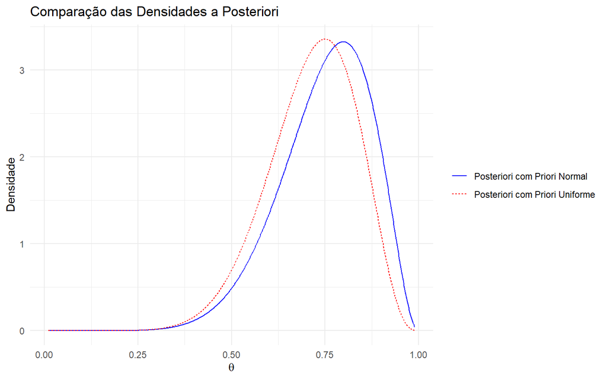

### **Questao 4**

No exercício 2, calcule:

##### **(i)** a estimativa bayesiana para Perda Quadrática

Para calcular a estimativa Bayesiana sob a perda quadrática, precisamos encontrar o estimador que minimiza o valor esperado da perda quadrática, geralmente expressa como:

$L(\theta, d) = (\theta - d)^2$

onde $\theta$ é o parâmetro verdadeiro e $d$ é a decisão ou estimativa tomad (em alguns lugares pode ser escrito como $\hat\theta$). Assim, temos:

$$\mathbb{E}\left[(\theta - d)^2 \mid y_1, y_2, \ldots, y_n\right]$$

onde $\theta$ segue a distribuição a posteriori dado os dados observados $y_1, y_2, \ldots, y_n$.

Dado que $\theta$ tem distribuição a posteriori $\operatorname{Beta}(k+1, n-k+1)$, a estimativa Bayesiana que minimiza a perda quadrática é a média da distribuição a posteriori, pois a média de uma distribuição é o estimador de mínimo erro quadrático médio (MSE).

A média da distribuição $\operatorname{Beta}(\alpha, \beta)$ é dada por:

$$\frac{\alpha}{\alpha + \beta}$$

Portanto, para a nossa distribuição a posteriori $\operatorname{Beta}(k+1, n-k+1)$, a média é:

$$\mathbb{E}\left[\theta \mid y_1, y_2, \ldots, y_n\right] =
\frac{k+1}{(k+1) + (n-k+1)} = \frac{k+1}{n+2}$$

Consequentemente, a estimativa Bayesiana de $\theta$ sob perda quadrática, dada a amostra $\left[y_1, y_2, \ldots, y_n\right]$, é:

$$d^* = \frac{k+1}{n+2}$$

A estimativa Bayesiana $d^*$ corresponde à média a posteriori do parâmetro $\theta$, considerando tanto a informação a priori (distribuição uniforme de $\theta$ entre 0 e 1) quanto a evidência da amostra ($k$ sucessos em $n$ tentativas). O ajuste de $+1$ no numerador e $+2$ no denominador introduz uma regularização que evita extremos em amostras pequenas, promovendo uma suavização estatística. Isso reflete um equilíbrio entre o conhecimento a priori e a evidência empírica, alinhando-se com os princípios fundamentais da inferência Bayesiana.

##### **(ii)** o limite da estimativa bayesiana para Perda Zero-Um quando $\epsilon \rightarrow 0$. No caso especial que $n=12, s=\sum_{i=1}^{12} y_i=9$

A estimativa Bayesiana sob a função de perda zero-um é dada por:

$$L(\theta, d) =
\begin{cases}
1 & \text{se } \theta \neq d \\
0 & \text{se } \theta = d
\end{cases}$$

Essa função penaliza exclusivamente decisões incorretas, sem considerar a magnitude do erro, diferentemente da perda quadrática que penaliza com base no quadrado da diferença entre $\theta$ e $d$.

A minimização do erro de classificação ocorre ao selecionar o valor de $\theta$ que maximiza a distribuição a posteriori, ou seja, a **moda** da distribuição a posteriori.

Dado o caso especial em que $n=12$ e $s=\sum_{i=1}^{12} y_i = 9$, a distribuição a posteriori de $\theta$ é:

$$\theta \mid y_1, y_2, \ldots, y_{12} \sim \operatorname{Beta}(s+1,
n-s+1) = \operatorname{Beta}(10, 4)$$

A moda de uma distribuição $\operatorname{Beta}(\alpha, \beta)$, para $\alpha > 1$ e $\beta > 1$, é calculada como:

$$\operatorname{Mode}[\theta] = \frac{\alpha - 1}{\alpha + \beta - 2}$$

Aplicando aos nossos parâmetros $\operatorname{Beta}(10, 4)$:

$$\operatorname{Mode}[\theta] = \frac{10 - 1}{10 + 4 - 2} = \frac{9}{12} =
0.75$$

O limite $\epsilon \rightarrow 0$ normalmente implica analisar o comportamento extremo da função de perda ou dos parâmetros. Nesse contexto, considerando a estimativa para a função de perda zero-um, já calculamos que o valor da moda é:

$$\theta^* = 0.75$$

Não há dependência explícita de $\epsilon$ no cálculo, a menos que $\epsilon$ esteja associado a algum parâmetro adicional de regularização ou suavização não especificado na questão. O valor calculado reflete a solução ótima considerando os dados e a função de perda zero-um.

##### **(iii)** a estimativa bayesiana sob Perda Absoluta

A estimativa Bayesiana sob a perda absoluta é obtida minimizando o valor esperado da perda absoluta. A função de perda absoluta é dada por:

$$L(\theta, d) = |\theta - d|$$

onde $\theta$ é o parâmetro verdadeiro e $d$ é a decisão ou estimativa tomada. O estimador que minimiza a perda absoluta é a **mediana** da distribuição a posteriori, pois a mediana minimiza a soma das distâncias absolutas em relação a ela mesma.

Após observar os dados $y_1, y_2, \ldots, y_n$, a distribuição a posteriori de $\theta$ é:

$$\theta \mid y_1, y_2, \ldots, y_n \sim \operatorname{Beta}(k+1, n-k+1)$$

onde $k = \sum_{i=1}^n y_i$. No caso especial em que $n = 12$ e $k = s = 9$, temos:

$$\theta \mid y_1, y_2, \ldots, y_{12} \sim \operatorname{Beta}(10, 4)$$

Para uma distribuição $\operatorname{Beta}(\alpha, \beta)$, a mediana não possui uma fórmula fechada simples, mas pode ser aproximada ou calculada numericamente. Uma aproximação comum é:

$$\text{Mediana} \approx \frac{\alpha - \frac{1}{3}}{\alpha + \beta -
\frac{2}{3}}$$

Substituindo $\alpha = 10$ e $\beta = 4$:

$$\text{Mediana} \approx \frac{10 - \frac{1}{3}}{10 + 4 - \frac{2}{3}} =
\frac{9.6667}{13.3333} \approx 0.725$$

Portanto, a estimativa Bayesiana de $\theta$ sob a perda absoluta, dada a amostra específica, é aproximadamente:

$$\theta^* \approx 0.725$$

##### **(iv)** um intervalo HPD com nível $99 \%$.

O intervalo de alta densidade posterior (HPD - Highest Posterior Density) é definido como o intervalo que contém uma determinada percentagem da densidade de probabilidade, onde todas as probabilidades dentro do intervalo são maiores ou iguais às probabilidades fora dele.

Para calcular o intervalo HPD de 99% para a distribuição a posteriori de $\theta$, assumimos que $\theta \sim \operatorname{Beta}(10,4)$. A função de densidade da distribuição Beta é dada por:

$$f(\theta; \alpha, \beta) = \frac{\theta^{\alpha-1}
(1-\theta)^{\beta-1}}{B(\alpha, \beta)}$$

onde $B(\alpha, \beta)$ é a função Beta. Para nosso caso específico, $\alpha = 10$ e $\beta = 4$.

```r
# Parâmetros da Beta
a <- 10
b <- 4

# Função para calcular o intervalo HPD
hpd_interval <- function(a, b, level = 0.99) {
  lower_bound <- (1 - level) / 2
  upper_bound <- 1 - lower_bound

  lower_quantile <- qbeta(lower_bound, a, b)
  upper_quantile <- qbeta(upper_bound, a, b)

  return(c(lower_quantile, upper_quantile))
}

# Calcular o intervalo HPD de 99%
hpd_99 <- hpd_interval(a, b, 0.99)

# Formatando os resultados
hpd_99_formatted <- round(hpd_99, 3)
```

```
## Intervalo HPD de 99% para Beta(10, 4): (0.379, 0.943)
```

### **Questao 7**

Suponha que $x_1, \ldots, x_5 \stackrel{i i d}{\sim}$ Cauchy $(\theta, 1)$ (i.é. $p\left(y_1 \mid \theta\right)=\pi^{-1} /\left[1+\left(y_1-\theta\right)^2\right]$ para $\left.-\infty<y_1<\infty\right)$. Assuma que a sua distribuição a priori para $\theta$ é Uniforme $(0,1)$. Dadas as observações $\left(x_1, \ldots, x_5\right)=(-2,-1,0,1.5,2.5)$ :

##### **(i)** Compute a densidade a posteriori não normalizada [isto é, $p(\theta) p\left(x_1, \ldots, x_5 \mid \theta\right)$ ] numa grade de pontos $\theta=0, \frac{1}{m}, \frac{2}{m}, \ldots, \frac{m-1}{m}, 1$ para algum valor grande de $m$.

```r
# Vetor de dados
x <- c(-2, -1, 0, 1.5, 2.5)
n <- length(x)

# Número de pontos em theta
m <- 1000
theta <- seq(0, 1, length.out = m)

# Função para calcular a densidade posterior
posterior_density <- function(theta, x) {
  likelihood <- sapply(theta, function(t) prod(1 / (pi * (1 + (x - t)^2))))
  prior <- rep(1, length(theta)) # Prior uniforme
  return(likelihood * prior)
}

# Calcular a densidade posteriori
posterior <- posterior_density(theta, x)

# Normalizar a posteriori utilizando a regra do trapézio
posterior <- posterior / trapz(theta, posterior)
```

##### **(ii)** Usando essa grade, calcule uma aproximaçāo para $p\left(\theta \mid x_1, \ldots, x_5\right)$ e faça um gráfico dela.

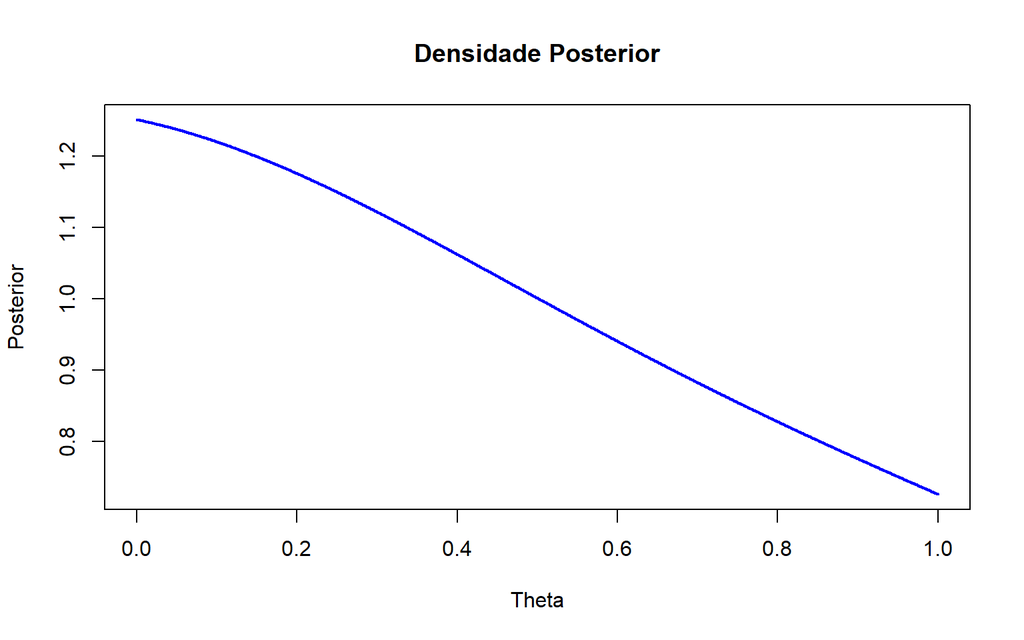

```r
plot(theta, posterior, type = "l", col = "blue", lwd = 2, main = "Densidade Posterior", xlab = "Theta", ylab = "Posterior")
```

##### **(iii)** Amostre 1000 observações da distribuç̧ão a posteriori aproximada e faça um histograma dessa amostra.

```r
set.seed(42) # Para reprodutibilidade
# Amostrar 1000 observações da distribuição posterior
sample_posterior <- sample(theta, size = 1000, prob = posterior, replace = TRUE)
```

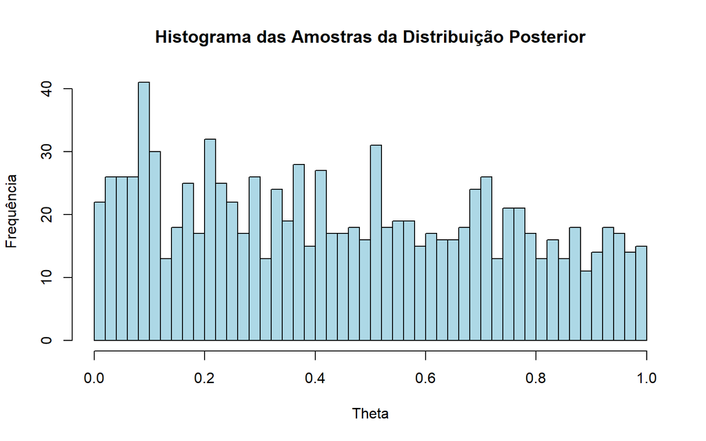

```r
# Criar o histograma da amostra
hist(sample_posterior, breaks = 60, col = "lightblue", border = "black",
     main = "Histograma das Amostras da Distribuição Posterior",
     xlab = "Theta", ylab = "Frequência")
```

##### **(iv)** Usando a amostra da parte (iii), amostre 1000 observações da distribuição preditiva de uma observação futura $y_6$. Calcule a média e faça um histograma dessa amostra.

```r
# Configuração inicial (usando a amostra da posterior calculada anteriormente)

# Gerar a distribuição preditiva para uma nova observação y6
predictive_sample <- sapply(sample_posterior, function(theta_i) {
  # Gerar uma observação de y6 para cada theta amostrado
  rcauchy(1, location = theta_i, scale = 1) # A função rcauchy gera valores da distribuição de Cauchy
})

# Calcular a média da amostra da distribuição preditiva
mean_predictive <- mean(predictive_sample)

# Exibir a média
cat(sprintf("Média da distribuição preditiva: %.3f\n", mean_predictive))
```

```
## Média da distribuição preditiva: 1.262
```

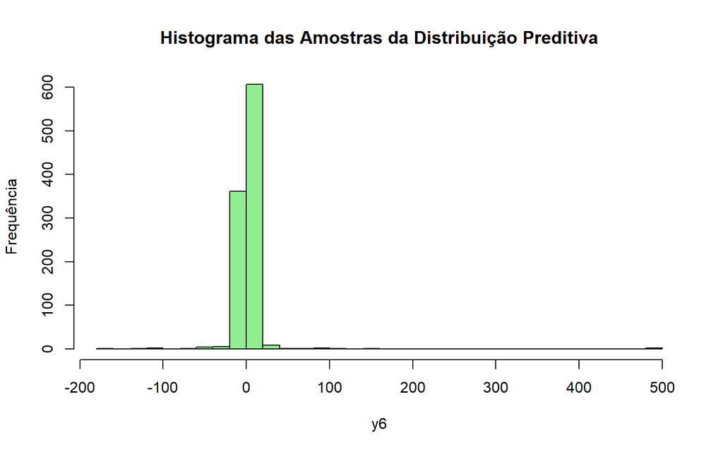

```r
# Criar o histograma da distribuição preditiva
hist(predictive_sample, breaks = 30, col = "lightgreen", border = "black",
     main = "Histograma das Amostras da Distribuição Preditiva",
     xlab = "y6", ylab = "Frequência")
```

### **Questao 8**

Suponha que $\left(x_1, x_2, x_3\right)$ dado $p_1, p_2, p_3$ segue uma distribuição Multinomial com parâmetros $n$ e $\left(p_1, p_2, p_3\right)$, onde $p_i \geq 0$ e $p_1+p_2+p_3=1$, e que, a priori, $\left(p_1, p_2, p_3\right)$ segue uma distribuição de Dirichlet com parâmetros $\left(\alpha_1, \alpha_2, \alpha_3\right)$.

#### **(i)** Ache a distribuição a posteriori de $p_1, p_2, p_3$ e as distribuições a posteriori marginais de $p_i(i=1,2,3)$

A distribuição a posteriori de $\left(p_1, p_2, p_3\right)$ é uma distribuição de Dirichlet com parâmetros atualizados. A distribuição a priori é:

$$\left(p_1, p_2, p_3\right) \sim \operatorname{Dirichlet}\left(\alpha_1,
\alpha_2, \alpha_3\right)$$

A função de verossimilhança para a distribuição multinomial é:

$$P\left(x_1, x_2, x_3 \mid p_1, p_2, p_3\right) = \frac{n!}{x_1!x_2!x_3!}
p_1^{x_1} p_2^{x_2} p_3^{x_3}$$

Portanto, a distribuição a posteriori é proporcional a:

$$P\left(p_1, p_2, p_3 \mid x_1, x_2, x_3\right) \propto
p_1^{\alpha_1+x_1-1} p_2^{\alpha_2+x_2-1} p_3^{\alpha_3+x_3-1}$$

A distribuição a posteriori é então:

$$\left(p_1, p_2, p_3\right) \mid \left(x_1, x_2, x_3\right) \sim
\operatorname{Dirichlet}\left(\alpha_1+x_1, \alpha_2+x_2,
\alpha_3+x_3\right)$$

Para calcular as marginais de cada $p_i$ vamos usar uma propriedade da distribuição Dirichlet onde suas marginais seguem uma beta com os seguintes parametros:

A densidade marginal de $x_i$ é dada por:
$$X_i \sim \operatorname{Beta}\left(\alpha_i, \alpha_0-\alpha_i\right),$$
onde: - $\alpha_0=\sum_{i=1}^K \alpha_i$ é a soma dos parâmetros da Dirichlet, - $X_i$ é a proporção associada ao $i$-ésimo componente.

Entao o resultados das marginais de $p_1,p_2,p_3$ fica:

- Para $p_1$:

$$p_1 \mid \left(x_1, x_2, x_3\right) \sim
\operatorname{Beta}\left(\alpha_1+x_1, \alpha_2+x_2+\alpha_3+x_3\right)$$

- Para $p_2$:

$$p_2 \mid \left(x_1, x_2, x_3\right) \sim
\operatorname{Beta}\left(\alpha_2+x_2, \alpha_1+x_1+\alpha_3+x_3\right)$$

- Para $p_3$:

$$p_3 \mid \left(x_1, x_2, x_3\right) \sim
\operatorname{Beta}\left(\alpha_3+x_3, \alpha_1+x_1+\alpha_2+x_2\right)$$

#### **(ii)** Calcule as estimativas bayesianas de $p_i$ e de $p_j-p_i$ sob Perda Quadrática $(i, j=1,2,3$, $i \neq j)$.

Para a distribuição Dirichlet $\operatorname{Dirichlet}\left(\alpha_1, \alpha_2, \alpha_3\right)$, a esperança de $p_i$ é:

$$\mathbb{E}\left[p_i \mid x_1, x_2, x_3\right] =
\frac{\alpha_i+x_i}{\sum_{j=1}^3 \left(\alpha_j+x_j\right)}$$

As estimativas Bayesianas de $p_1, p_2, p_3$ são:

$$\hat{p_1} = \frac{\alpha_1+x_1}{\alpha_1+x_1+\alpha_2+x_2+\alpha_3+x_3},
\quad
\hat{p_2} = \frac{\alpha_2+x_2}{\alpha_1+x_1+\alpha_2+x_2+\alpha_3+x_3},
\quad
\hat{p_3} = \frac{\alpha_3+x_3}{\alpha_1+x_1+\alpha_2+x_2+\alpha_3+x_3}$$

Para calcular a estimativa de $p_j - p_i$ sob perda quadrática, usamos a linearidade da esperança:

$$\mathbb{E}\left[p_j - p_i \mid x_1, x_2, x_3\right] =
\mathbb{E}\left[p_j \mid x_1, x_2, x_3\right] - \mathbb{E}\left[p_i \mid
x_1, x_2, x_3\right]$$

A estimativa é dada por:

$$\mathbb{E}\left[p_j - p_i \mid x_1, x_2, x_3\right] =
\frac{\alpha_j+x_j}{\alpha_1+x_1+\alpha_2+x_2+\alpha_3+x_3} -
\frac{\alpha_i+x_i}{\alpha_1+x_1+\alpha_2+x_2+\alpha_3+x_3}$$

Resumindo os resultados encontrados:

- A distribuição a posteriori de $\left(p_1, p_2, p_3\right)$ é $\operatorname{Dirichlet}\left(\alpha_1+x_1, \alpha_2+x_2, \alpha_3+x_3\right)$.
- As distribuições marginais de $p_i$ são $\operatorname{Beta}\left(\alpha_i+x_i, \sum_{j \neq i} \left(\alpha_j+x_j\right)\right)$.
- As estimativas Bayesianas de $p_i$ são:

$$\hat{p_i} = \frac{\alpha_i+x_i}{\sum_{j=1}^3 \left(\alpha_j+x_j\right)}$$

- As estimativas Bayesianas de $p_j - p_i$ são:

$$\hat{p_j} - \hat{p_i} = \frac{\alpha_j+x_j}{\sum_{k=1}^3
\left(\alpha_k+x_k\right)} - \frac{\alpha_i+x_i}{\sum_{k=1}^3
\left(\alpha_k+x_k\right)}$$

### **Questao 9**

Na véspera do primeiro turno para a eleição de governador do DF de 2010, a Datafolha divulgou uma pesquisa indicando que, de 891 eleitores entrevistados que já tinham decidido em quem votar, Agnelo Queiroz tinha a preferência de 467, Weslian Roriz a de 315 e outros candidatos a de 109 eleitores. Formule um modelo para analizar esses dados. Ache estimativas bayesianas e construa intervalos críveis para:

##### (a) a proporção de votantes de Agnelo Queiroz

1. Assumimos que a proporção de votantes de Agnelo Queiroz ($\theta_A$) segue uma distribuição Beta com parâmetros $a$ e $b$:

$$\theta_A \sim \operatorname{Beta}(a, b)$$

2. A verossimilhança baseada nos dados observados segue uma distribuição binomial:

$$x_A \sim \operatorname{Binomial}(n=891, p=\theta_A)$$

3. Dados observados:
   - Número de votantes de Agnelo Queiroz: $x_A = 467$
   - Total de eleitores decididos: $n = 891$
4. A distribuição a posteriori de $\theta_A$ é dada por:

$$\theta_A \sim \operatorname{Beta}(a + x_A, b + n - x_A)$$

5. Considerando uma distribuição a priori não informativa com $a = 1$ e $b = 1$, a posteriori é:

$$\theta_A \sim \operatorname{Beta}(1 + 467, 1 + 891 - 467) =
\operatorname{Beta}(468, 425)$$

6. Calculamos o intervalo crível de 95% para $\theta_A$ com base na distribuição a posteriori.

##### (b) a diferença entre a proporção de votantes de Agnelo e de Weslian Roriz.

Para este cenário, alteramos alguns parâmetros em relação ao passo anterior:

1. A priori para a proporção de votantes de Weslian Roriz ($\theta_W$) é:

$$\theta_W \sim \operatorname{Beta}(a, b$$

2. Dados observados:
   - Número de votantes de Weslian Roriz: $x_W = 315$
   - Total de eleitores decididos: $n = 891$
3. A posteriori de $\theta_W$ é:

$$\theta_W \sim \operatorname{Beta}(a + x_W, b + n - x_W)$$
Considerando $a = 1$ e $b = 1$, temos:

$$\theta_W \sim \operatorname{Beta}(1 + 315, 1 + 891 - 315) =
\operatorname{Beta}(316, 577)$$

4. Para encontrar a distribuição da diferença $\delta$ entre as proporções ($\theta_A - \theta_W$):
   - Amostramos valores de $\theta_A \sim \operatorname{Beta}(468, 425)$.
   - Amostramos valores de $\theta_W \sim \operatorname{Beta}(316, 577)$.
   - Calculamos a diferença $\delta = \theta_A - \theta_W$.
5. Por fim, calculamos o intervalo crível de 95% para $\delta$ com base nas amostras geradas.

Segue a implementação para os dois cenários:

```r
# Parâmetros
n <- 891
x_A <- 467
x_W <- 315

a <- 1
b <- 1

# Parâmetros da distribuição Beta
alpha_A_post <- a + x_A
beta_A_post <- b + (n - x_A)
alpha_W_post <- a + x_W
beta_W_post <- b + (n - x_W)

# Gerando amostras
library(extraDistr)

set.seed(123) # Para reprodutibilidade
samples_theta_A <- rbeta(10000, alpha_A_post, beta_A_post)
samples_theta_W <- rbeta(10000, alpha_W_post, beta_W_post)

# Intervalos de confiança
cred_interval_A <- quantile(samples_theta_A, probs = c(0.025, 0.975))
cred_interval_delta <- quantile(samples_theta_A - samples_theta_W, probs = c(0.025, 0.975))

# Arredondando os valores
cred_interval_A_rounded <- round(cred_interval_A, 2)
cred_interval_delta_rounded <- round(cred_interval_delta, 2)

# Resultados
cat("IC votantes de Agnelo Queiroz:", cred_interval_A_rounded, "\n")
```

```
## IC votantes de Agnelo Queiroz: 0.49 0.56
```

```r
cat("IC da diferença:", cred_interval_delta_rounded, "\n")
```

```
## IC da diferença: 0.12 0.22
```

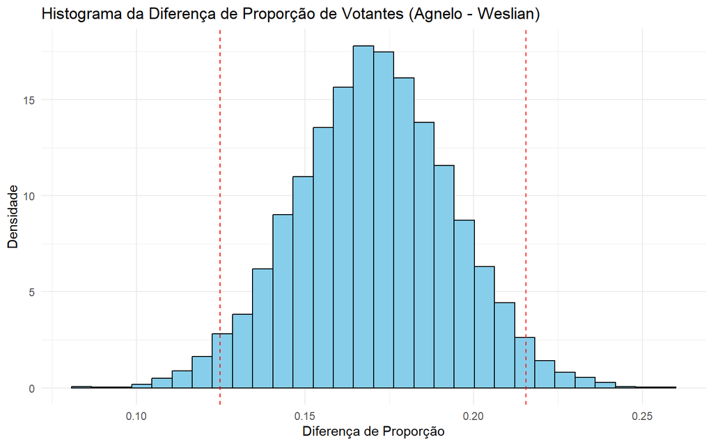

```r
# Visualização
library(ggplot2)

samples_delta <- samples_theta_A - samples_theta_W
ggplot(data.frame(samples_delta), aes(x = samples_delta)) +
  geom_histogram(aes(y = ..density..), bins = 30, fill = "skyblue", color = "black") +
  geom_vline(xintercept = cred_interval_delta[1], color = "red", linetype = "dashed", label = "Limite Inferior 95%") +
  geom_vline(xintercept = cred_interval_delta[2], color = "red", linetype = "dashed", label = "Limite Superior 95%") +
  labs(
    x = "Diferença de Proporção",
    y = "Densidade",
    title = "Histograma da Diferença de Proporção de Votantes (Agnelo - Weslian)"
  ) +
  theme_minimal()
```

### **Questao 11**

#### **(i)** Especifique a hipótese nula $H_0$ e a alternativa $H_1$;

- Hipótese nula $H_0: \theta=0.25$ (a droga nova é tão eficaz quanto o placebo)
- Hipótese alternativa $H_1: \theta>0.25$ (a droga nova é mais eficaz que o placebo)

#### **(ii)** Usando a distribuição a priori “não informativa” $\theta \sim$ Uniforme $(0,1)$, calcule as chances relativas a priori e a posteriori de $H_1$ e o correspondente Fator de Bayes;

- $P(\theta>0.25)$
- $P(\theta \leq 0.25)$

A distribuição a priori uniforme $\theta \sim \operatorname{Uniforme}(0,1)$ :

$$\begin{aligned}
& P(\theta \leq 0.25)=0.25 \\
& P(\theta>0.25)=1-0.25=0.75
\end{aligned}$$

As chances relativas a priori:

$$O\left(H_1\right)=\frac{P(\theta>0.25)}{P(\theta \leq
0.25)}=\frac{0.75}{0.25}=3$$

Sabemos que a distribuição a posteriori é $\theta \mid s \sim \operatorname{Beta}(9,13)$. Probabilidade a Posteriori de $\theta>0.25$ :

$$P(\theta>0.25 \mid s)=1-F_{\text {Beta }}(0.25 \mid 9,13)$$

Consequentemente:

$$P(\theta \leq 0.25 \mid s)=F_{\text {Beta }}(0.25 \mid 9,13)$$

```r
# Parâmetros da distribuição Beta
a <- 9
b <- 13

# Cálculo das probabilidades posteriores
posterior_prob_H1 <- 1 - pbeta(0.25, shape1 = a, shape2 = b)
posterior_prob_H0 <- pbeta(0.25, shape1 = a, shape2 = b)

# Exibindo os resultados
cat(sprintf("P(θ > 0.25 | s) = %.3f\n", posterior_prob_H1))
```

```
## P(θ > 0.25 | s) = 0.944
```

```r
cat(sprintf("P(θ ≤ 0.25 | s) = %.3f\n", posterior_prob_H0))
```

```
## P(θ ≤ 0.25 | s) = 0.056
```

Chances Relativas a Posteriori:
$$O\left(H_1 \mid s\right)=\frac{P(\theta>0.25 \mid s)}{P(\theta \leq
0.25 \mid s)}=\frac{0.944}{0.056}=16.810$$

Fator de Bayes:
$$B_{10}(s)=\frac{O\left(H_1 \mid
s\right)}{O\left(H_1\right)}=\frac{16.810}{3}=5.603$$

#### **(iii)** Seja $d=1$ a decisão de rejeitar $H_0$ e $d=0$ a de não rejeitar. Considere a função de perda de Neyman para a qual é 5 vezes mais custoso rejeitar $H_0$ quando ela é verdadeira do que não rejeitar quando ela é falsa [isto é, $\left.L\left(d=1, \theta \in H_0\right)=5 L\left(d=0, \theta \notin H_0\right), L\left(d=1, \theta \notin H_0\right)=L\left(d=0, \theta \in H_0\right)=0\right]$. Calcule a decisão ótima a posteriori;

Definindo a função de perda de Neyman:

Considerando a função de perda de Neyman:

- $a_0=L(d=1, \theta \leq 0.25)=5 L(d=0, \theta \leq 0.25)=5 a_1$

A decisão ótima é rejeitar $H_0$ se:

$$P(\theta>0.25 \mid s)>\frac{a_0}{a_0+a_1}=\frac{5 a_1}{5
a_1+a_1}=\frac{5}{6}=0.833$$

Como $P(\theta>0.25 \mid s)=0.944$ é maior do que 0.833 , a decisão ótima é rejeitar $H_0$.

#### **(iv)** É razoável chamar essa distribuição a priori de “nāo informativa” nesse problema? Se a sua resposta for negativa, sugira uma outra distribuição a priori e refaça os cálculos anteriores.

Uma distribuição uniforme pode ser considerada “não informativa” em determinado contexto, embora nem sempre seja a escolha mais apropriada. Para hipóteses específicas, como $H_0$ e $H_1$, uma distribuição Beta pode oferecer maior relevância informativa.

A priori uniforme favorece $H_1$, já que $P(\theta > 0.25) = 3P(\theta \leq 0.25)$. Para ajustar esse desequilíbrio, pode-se empregar uma distribuição Beta com $\beta = 3\alpha$, o que resulta em uma alternativa para a priori imprópria:
$$\theta \sim \operatorname{Beta}(\alpha, 3 \alpha)$$

Para obter uma variância maximizada, precisamos definir $\alpha \rightarrow 0$. Então:
$$P(\theta) \propto \frac{1}{\theta(1-\theta)}$$

Com a priori imprópria $P(\theta) \propto \frac{1}{\theta(1-\theta)}$, a distribuição a posteriori é proporcional a:
$$P(\theta \mid s) \propto P(s \mid \theta) P(\theta) \propto
\theta^s(1-\theta)^{n-s} \cdot
\frac{1}{\theta(1-\theta)}=\theta^{s-1}(1-\theta)^{n-s-1}$$

Isto é uma distribuição $\operatorname{Beta}(s, n-s)$. Para $n=20$ e $s=8$ :
$$\theta \mid s \sim \operatorname{Beta}(8,12)$$